# IDS investigation worksheet

Xu Sun

2025-11-17

**Note:** You can use this file as you ‘working document’ where you can try out various investigation ideas and keep notes about your findings. How you use and structure this file is up to you. It is recommended that you keep notes about what you are investigating and what you find as this will make the process of creating your presentation and report easier. Please note that you *do not* need to submit this file as part of your group project.

```r
library(tidyverse)
library(ggplot2)
# Add any other libraries here
```

```r
# Load my data
communities <- read_csv("data/communities.data")
glimpse(communities)
```

```
## Rows: 1,994
## Columns: 128
## $ state                 <dbl> 8, 53, 24, 34, 42, 6, 44, 6, 21, 29, 6, 36, 25, …
## $ county                <dbl> NA, NA, NA, 5, 95, NA, 7, NA, NA, NA, NA, NA, 21…
## $ community             <dbl> NA, NA, NA, 81440, 6096, NA, 41500, NA, NA, NA, …
## $ communityname         <chr> "Lakewoodcity", "Tukwilacity", "Aberdeentown", "…
## $ fold                  <dbl> 1, 1, 1, 1, 1, 1, 1, 1, 1, 1, 1, 1, 1, 1, 1, 1, …
## $ population            <dbl> 0.19, 0.00, 0.00, 0.04, 0.01, 0.02, 0.01, 0.01, …
## $ householdsize         <dbl> 0.33, 0.16, 0.42, 0.77, 0.55, 0.28, 0.39, 0.74, …
## $ racepctblack          <dbl> 0.02, 0.12, 0.49, 1.00, 0.02, 0.06, 0.00, 0.03, …
## $ racePctWhite          <dbl> 0.90, 0.74, 0.56, 0.08, 0.95, 0.54, 0.98, 0.46, …
## $ racePctAsian          <dbl> 0.12, 0.45, 0.17, 0.12, 0.09, 1.00, 0.06, 0.20, …
## $ racePctHisp           <dbl> 0.17, 0.07, 0.04, 0.10, 0.05, 0.25, 0.02, 1.00, …
## $ agePct12t21           <dbl> 0.34, 0.26, 0.39, 0.51, 0.38, 0.31, 0.30, 0.52, …
## $ agePct12t29           <dbl> 0.47, 0.59, 0.47, 0.50, 0.38, 0.48, 0.37, 0.55, …
```

[output cut: 115 more lines]

```r
# Remove identifiers & Check missing values
data <- communities %>%
  select(-c(state, county, community, communityname, fold))
colSums(is.na(data)) %>% sort(decreasing = TRUE)
```

```
##          LemasSwornFT       LemasSwFTPerPop     LemasSwFTFieldOps
##                  1675                  1675                  1675
##  LemasSwFTFieldPerPop         LemasTotalReq     LemasTotReqPerPop
##                  1675                  1675                  1675
##      PolicReqPerOffic           PolicPerPop    RacialMatchCommPol
##                  1675                  1675                  1675
##         PctPolicWhite         PctPolicBlack          PctPolicHisp
##                  1675                  1675                  1675
##         PctPolicAsian         PctPolicMinor   OfficAssgnDrugUnits
##                  1675                  1675                  1675
##      NumKindsDrugSeiz      PolicAveOTWorked             PolicCars
##                  1675                  1675                  1675
##         PolicOperBudg  LemasPctPolicOnPatrr   LemasGangUnitDeploy
##                  1675                  1675                  1675
##       PolicBudgPerPop           OtherPerCap            population
##                  1675                     1                     0
##         householdsize          racepctblack          racePctWhite
##                     0                     0                     0
##          racePctAsian           racePctHisp           agePct12t21
##                     0                     0                     0
##           agePct12t29           agePct16t24            agePct65up
##                     0                     0                     0
##             numbUrban              pctUrban             medIncome
##                     0                     0                     0
##              pctWWage          pctWFarmSelf            pctWInvInc
##                     0                     0                     0
##            pctWSocSec           pctWPubAsst            pctWRetire
##                     0                     0                     0
##             medFamInc             perCapInc          whitepPerCap
##                     0                     0                     0
##           blackPerCap          indianPerCap           AsianPerCap
##                     0                     0                     0
##            HispPerCap           NumUnderPov        PctPopUnderPov
##                     0                     0                     0
##       PctLess9thGrade          PctNotHSGrad           PctBSorMore
##                     0                     0                     0
##         PctUnemployed             PctEmploy           PctEmplManu
##                     0                     0                     0
##       PctEmplProfServ          PctOccupManu      PctOccupMgmtProf
##                     0                     0                     0
```

[output cut: 27 more lines]

```
##                     0                     0                     0
##          OwnOccMedVal         OwnOccHiQuart              RentLowQ
##                     0                     0                     0
##            RentMedian             RentHighQ               MedRent
##                     0                     0                     0
##     MedRentPctHousInc      MedOwnCostPctInc MedOwnCostPctIncNoMtg
##                     0                     0                     0
##         NumInShelters             NumStreet        PctForeignBorn
##                     0                     0                     0
##      PctBornSameState        PctSameHouse85         PctSameCity85
##                     0                     0                     0
##        PctSameState85              LandArea               PopDens
##                     0                     0                     0
##        PctUsePubTrans   LemasPctOfficDrugUn   ViolentCrimesPerPop
##                     0                     0                     0
```

```r
data_clean <- data %>% select(where(~ mean(is.na(.)) < 0.3))
data_clean <- data_clean %>% mutate(across(everything(), ~ replace_na(., mean(., na.rm = TRUE))))

str(data_clean)
```

```
## tibble [1,994 × 101] (S3: tbl_df/tbl/data.frame)
##  $ population           : num [1:1994] 0.19 0 0 0.04 0.01 0.02 0.01 0.01 0.03 0.01 ...
##  $ householdsize        : num [1:1994] 0.33 0.16 0.42 0.77 0.55 0.28 0.39 0.74 0.34 0.4 ...
##  $ racepctblack         : num [1:1994] 0.02 0.12 0.49 1 0.02 0.06 0 0.03 0.2 0.06 ...
##  $ racePctWhite         : num [1:1994] 0.9 0.74 0.56 0.08 0.95 0.54 0.98 0.46 0.84 0.87 ...
##  $ racePctAsian         : num [1:1994] 0.12 0.45 0.17 0.12 0.09 1 0.06 0.2 0.02 0.3 ...
##  $ racePctHisp          : num [1:1994] 0.17 0.07 0.04 0.1 0.05 0.25 0.02 1 0 0.03 ...
##  $ agePct12t21          : num [1:1994] 0.34 0.26 0.39 0.51 0.38 0.31 0.3 0.52 0.38 0.9 ...
##  $ agePct12t29          : num [1:1994] 0.47 0.59 0.47 0.5 0.38 0.48 0.37 0.55 0.45 0.82 ...
##  $ agePct16t24          : num [1:1994] 0.29 0.35 0.28 0.34 0.23 0.27 0.23 0.36 0.28 0.8 ...
##  $ agePct65up           : num [1:1994] 0.32 0.27 0.32 0.21 0.36 0.37 0.6 0.35 0.48 0.39 ...
##  $ numbUrban            : num [1:1994] 0.2 0.02 0 0.06 0.02 0.04 0.02 0 0.04 0.02 ...
##  $ pctUrban             : num [1:1994] 1 1 0 1 0.9 1 0.81 0 1 1 ...
##  $ medIncome            : num [1:1994] 0.37 0.31 0.3 0.58 0.5 0.52 0.42 0.16 0.17 0.54 ...
##  $ pctWWage             : num [1:1994] 0.72 0.72 0.58 0.89 0.72 0.68 0.5 0.44 0.47 0.59 ...
```

[output cut: 86 more lines]

```r
summary(data_clean$ViolentCrimesPerPop)
```

```
##    Min. 1st Qu.  Median    Mean 3rd Qu.    Max.
##   0.000   0.070   0.150   0.238   0.330   1.000
```

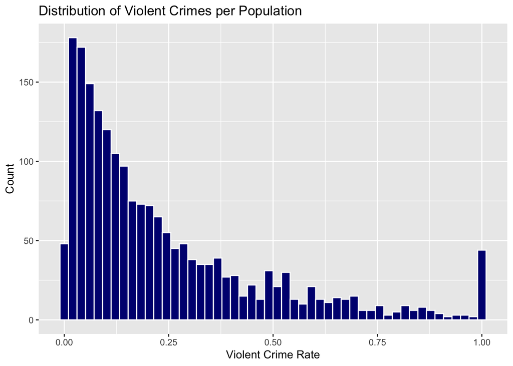

```r
# Distribution of Violent Crime
ggplot(data = data_clean, mapping = aes(x = ViolentCrimesPerPop)) +
  geom_histogram(bins = 50, fill = "navyblue", color = "white") +
  labs(title = "Distribution of Violent Crimes per Population", x = "Violent Crime Rate", y = "Count")
```

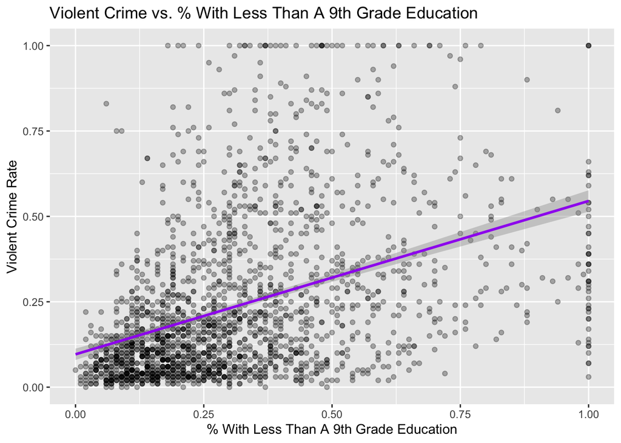

```r
# Education vs. Crime
ggplot(data = data_clean, mapping = aes(x = PctLess9thGrade, y = ViolentCrimesPerPop)) +
  geom_point(alpha = 0.3) +
  geom_smooth(method = "lm", color = "purple") +
  labs(title = "Violent Crime vs. % With Less Than A 9th Grade Education",
       x = "% With Less Than A 9th Grade Education",
       y = "Violent Crime Rate")
```

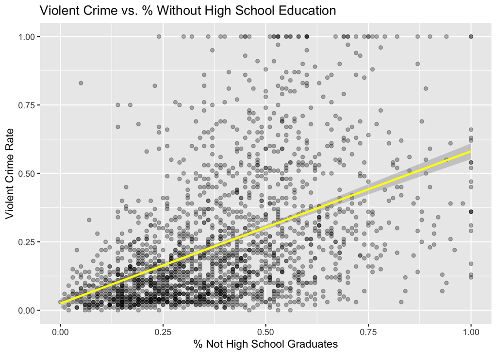

```r
ggplot(data = data_clean, mapping = aes(x = PctNotHSGrad, y = ViolentCrimesPerPop)) +
  geom_point(alpha = 0.3) +
  geom_smooth(method = "lm", color = "yellow") +
  labs(title = "Violent Crime vs. % Without High School Education",
       x = "% Not High School Graduates",
       y = "Violent Crime Rate")
```

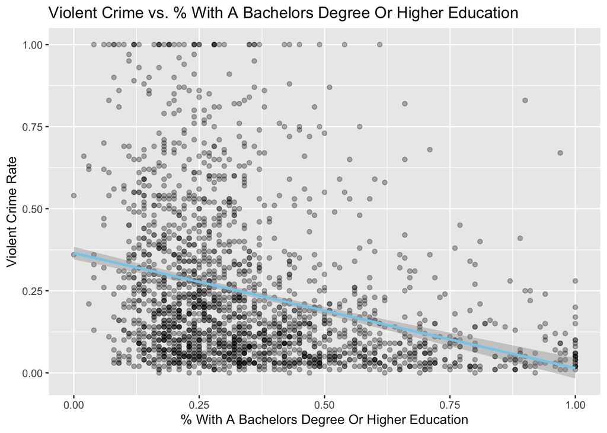

```r
ggplot(data = data_clean, mapping = aes(x = PctBSorMore, y = ViolentCrimesPerPop)) +
  geom_point(alpha = 0.3) +
  geom_smooth(method = "lm", color = "skyblue") +
  labs(title = "Violent Crime vs. % With A Bachelors Degree Or Higher Education",
       x = "% With A Bachelors Degree Or Higher Education",
       y = "Violent Crime Rate")
```

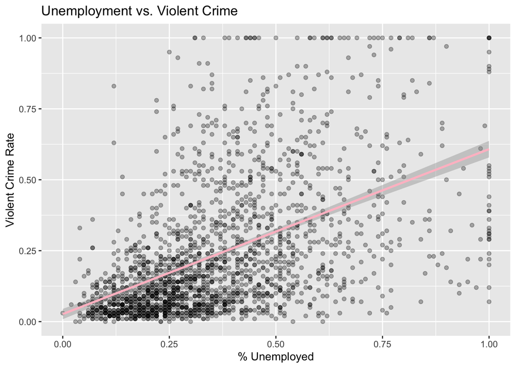

```r
# Unemployment vs. Crime (95% confidence)
ggplot(data = data_clean, mapping = aes(x = PctUnemployed, y = ViolentCrimesPerPop)) +
  geom_point(alpha = 0.3) +
  geom_smooth(method = "lm", color = "pink") +
  labs(title = "Unemployment vs. Violent Crime",
       x = "% Unemployed", y = "Violent Crime Rate")
```

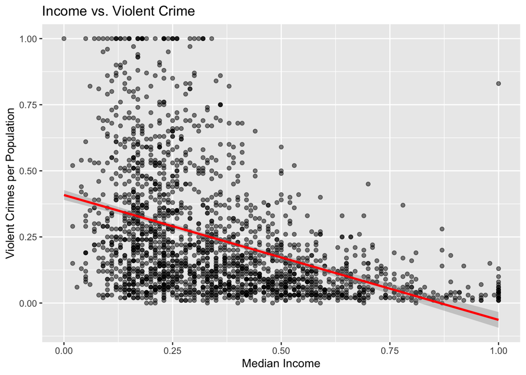

```r
#Income vs. Crime
ggplot(data_clean, aes(x = medIncome, y = ViolentCrimesPerPop)) +
  geom_point(alpha = 0.5, color = "black") +
  geom_smooth(method = "lm", color = "red") +
  labs(title = "Income vs. Violent Crime",
       x = "Median Income",
       y = "Violent Crimes per Population")
```

```r
# Correlation with Crime
correlations <- data_clean %>%
  select(-ViolentCrimesPerPop) %>%
  summarise(across(everything(), ~ cor(., data_clean$ViolentCrimesPerPop, use = "complete.obs"))) %>%
  pivot_longer(cols = everything(), names_to = "Variable", values_to = "Correlation") %>%
  arrange(desc(abs(Correlation)))
head(correlations, 30)
```

```
## # A tibble: 30 × 2
##    Variable         Correlation
##    <chr>                  <dbl>
##  1 PctKids2Par           -0.738
##  2 PctIlleg               0.738
##  3 PctFam2Par            -0.707
##  4 racePctWhite          -0.685
##  5 PctYoungKids2Par      -0.666
##  6 PctTeen2Par           -0.662
##  7 racepctblack           0.631
##  8 pctWInvInc            -0.576
##  9 pctWPubAsst            0.575
## 10 FemalePctDiv           0.556
## # ℹ 20 more rows
```

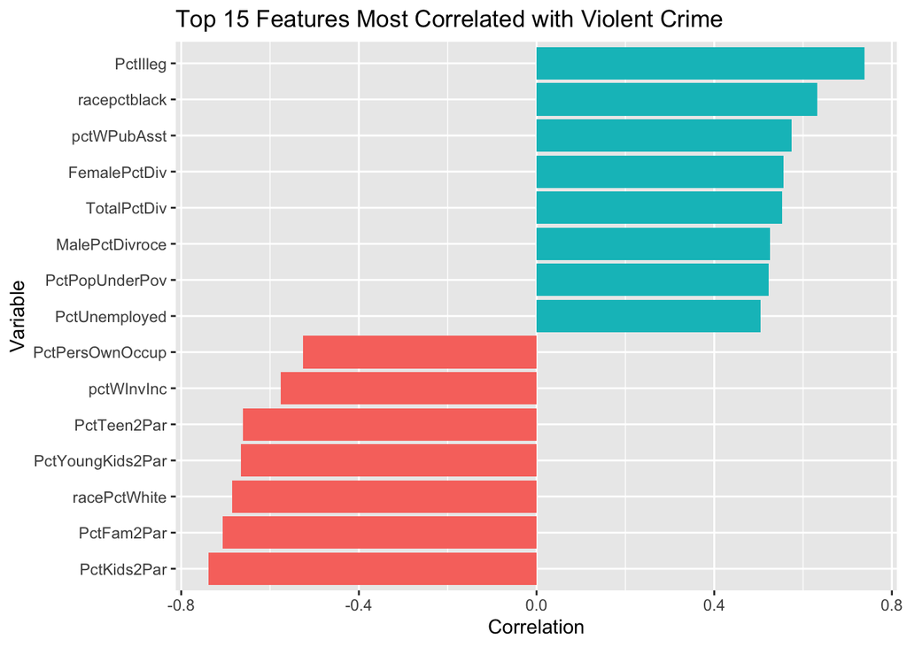

```r
# ~ cor(., data_clean$ViolentCrimesPerPop, use = "complete.obs")
# . represents the current column.
#   cor(x, y) computes Pearson correlation.
#   use = "complete.obs" removes rows containing NA in either variable.


correlations %>%
  top_n(15, abs(Correlation)) %>%
  ggplot(aes(x = reorder(Variable, Correlation), y = Correlation, fill = Correlation > 0)) +
  geom_col(show.legend = FALSE) +
  coord_flip() +
  labs(title = "Top 15 Features Most Correlated with Violent Crime",
       x = "Variable", y = "Correlation")
```

```r
top15_vars <- correlations %>%
  top_n(15, abs(Correlation)) %>%
  pull(Variable)
formula_top15 <- as.formula(
  paste("ViolentCrimesPerPop ~", paste(top15_vars, collapse = " + "))
)
model_top15 <- lm(formula_top15, data = communities)
summary(model_top15)
```

```
##
## Call:
## lm(formula = formula_top15, data = communities)
##
## Residuals:
##      Min       1Q   Median       3Q      Max
## -0.55996 -0.07883 -0.01389  0.05015  0.77062
##
## Coefficients:
##                   Estimate Std. Error t value Pr(>|t|)
## (Intercept)       0.377582   0.082477   4.578 4.99e-06 ***
## PctKids2Par      -0.628582   0.128235  -4.902 1.03e-06 ***
## PctIlleg          0.280715   0.039756   7.061 2.28e-12 ***
## PctFam2Par        0.316015   0.136352   2.318 0.020570 *
## racePctWhite     -0.231221   0.032157  -7.190 9.12e-13 ***
## PctYoungKids2Par  0.048769   0.047902   1.018 0.308759
## PctTeen2Par      -0.007284   0.044234  -0.165 0.869227
## racepctblack     -0.021985   0.031218  -0.704 0.481361
## pctWInvInc        0.039347   0.036889   1.067 0.286266
## pctWPubAsst       0.040578   0.034504   1.176 0.239718
## FemalePctDiv      0.866617   0.290822   2.980 0.002919 **
## TotalPctDiv      -1.452774   0.487173  -2.982 0.002898 **
## PctPersOwnOccup   0.007986   0.031411   0.254 0.799347
## MalePctDivroce    0.865404   0.227359   3.806 0.000145 ***
## PctPopUnderPov   -0.044962   0.030714  -1.464 0.143379
## PctUnemployed     0.028837   0.032983   0.874 0.382066
## ---
## Signif. codes:  0 '***' 0.001 '**' 0.01 '*' 0.05 '.' 0.1 ' ' 1
##
## Residual standard error: 0.1437 on 1978 degrees of freedom
## Multiple R-squared:  0.6226, Adjusted R-squared:  0.6198
## F-statistic: 217.6 on 15 and 1978 DF,  p-value: < 2.2e-16
```

```r
# Creates the beginning of the regression formula.
# "~" means predict using in R.
# paste(top15_vars, collapse = " + ") turns the vector into a single string:
# paste("ViolentCrimesPerPop ~", ...) combines the left-hand side (dependent variable) and the predictors

formula_full <- as.formula(
  paste("ViolentCrimesPerPop ~", paste(top15_vars, collapse = " + "))
)
model_full <- lm(formula_full, data = communities)
# Fits a multiple linear regression model using:
# dependent variable: ViolentCrimesPerPop
# independent variables: the 15 predictors
# dataset: communities
full_adj_r2 <- summary(model_full)$adj.r.squared # $adj.r.squared pulls the adjusted R² value
full_adj_r2
```

```
## [1] 0.6197867
```

```r
results <- data.frame(
  Removed_Variable = character(),
  Adjusted_R2 = numeric()
)

for (v in top15_vars) {
  remaining <- top15_vars[top15_vars != v]
  f <- reformulate(remaining, "ViolentCrimesPerPop")
#reformulate(rhs_vector, lhs_string) is a convenience function that creates a formula from character vectors.

  model <- lm(f, data = communities)
  results <- rbind(results, data.frame(
    Removed_Variable = v,
    Adjusted_R2 = summary(model)$adj.r.squared
  ))
}

results %>% arrange(desc(Adjusted_R2))
```

```
##    Removed_Variable Adjusted_R2
## 1       PctTeen2Par   0.6199737
## 2   PctPersOwnOccup   0.6199665
## 3      racepctblack   0.6198836
## 4     PctUnemployed   0.6198320
## 5  PctYoungKids2Par   0.6197797
## 6        pctWInvInc   0.6197603
## 7       pctWPubAsst   0.6197131
## 8    PctPopUnderPov   0.6195671
## 9        PctFam2Par   0.6189469
## 10     FemalePctDiv   0.6182729
## 11      TotalPctDiv   0.6182704
## 12   MalePctDivroce   0.6171953
## 13      PctKids2Par   0.6153626
## 14         PctIlleg   0.6104000
## 15     racePctWhite   0.6100458
```

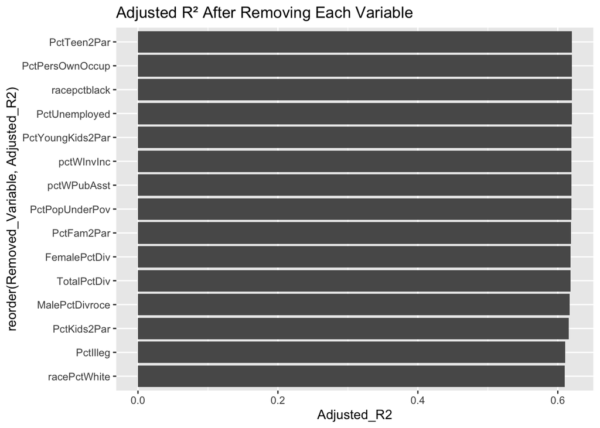

```r
ggplot(results, aes(x = reorder(Removed_Variable, Adjusted_R2), y = Adjusted_R2)) +
  geom_col() +
  coord_flip() +
  labs(title = "Adjusted R² After Removing Each Variable")
```

1. Pctllleg: percentage of kids born to never married (numeric - decimal) This may reflect community-level social disorganization — weaker social networks, less supervision, and more economic strain.

2. PctYoungKids2Par: percent of kids 4 and under in two parent households (numeric - decimal)
3. racePctWhite: percentage of population that is caucasian (numeric - decimal) A negative association indicates that under this dataset, communities with lower levels of White residents/inhabitants also tend to be associated with higher criminality levels (-0.68). ⚠️ Important: this does NOT mean that race causes crime, or not more than income, education, housing, or policing causes crime. The correlation may well represent systemic inequalities. (reflect upon it as a socioeconomic, correlated variable rather than a causal racial difference)
4. PctFam2Par: percentage of families (with kids) that are headed by two parents (numeric - decimal)
5. PctKids2Par: percentage of kids in family housing with two parents (numeric - decimal) From the correlation analysis, several strong relationships emerged between community family structure and violent crime rates. Variables such as PctKids2Par (-0.74), PctFam2Par (-0.71), and PctYoungKids2Par (-0.67) show strong negative correlations with violent crime, indicating that communities with fewer two-parent families tend to experience higher levels of violent crime.